# Chernobyl Radiation: Country-Level Exposure and Health Outcomes

Eliza

2026-04-10

## Background

The Chernobyl nuclear accident in April 1986 was the worst nuclear disaster in history. The explosion at Reactor No. 4 sent a large plume of radioactive material across Europe, with contamination levels varying a lot depending on wind patterns and distance from the plant. This report looks at radiation data from several European countries to see how contamination changed over time and what the health outcomes looked like.

The three main radionuclides I focused on are Cesium-137 (30-year half-life, the main long-term concern), Iodine-131 (8-day half-life, main cause of thyroid cancer risk in the short term), and Strontium-90 (29-year half-life, concentrates in bone).

## Data

The dataset comes from Kaggle and has country-level radiation measurements and health statistics for 18 countries across several time points from 1986 to 2016. I cleaned the data in `code/00_clean_data.R`.

## Summary Table

Table 1 shows average radiation exposure and health outcomes by region at the time of the accident (1986).

Table 1. Radiation exposure and health outcomes by region, 1986

| Region | n | Mean Cs-137 (Bq/m2) | Mean Distance (km) | Mean Pop. Exposed | Mean Thyroid Ca/100k | Mean Cancer Inc./100k |
| --- | --- | --- | --- | --- | --- | --- |
| Central Europe | 4 | 15,800 | 1,325 | 56,000 | 1.23 | 14.68 |
| Eastern Europe | 5 | 101,660 | 554 | 181,400 | 4.86 | 18.64 |
| Northern Europe | 2 | 31,500 | 1,800 | 36,500 | 1.30 | 16.35 |
| Southern Europe | 3 | 6,667 | 1,567 | 56,000 | 0.57 | 12.67 |
| Western Asia | 1 | 6,500 | 1,400 | 72,000 | 0.60 | 12.70 |
| Western Europe | 3 | 6,200 | 1,950 | 74,333 | 0.57 | 12.57 |

Eastern Europe had much higher contamination and worse health outcomes compared to Western and Northern Europe, which makes sense given their proximity to Chernobyl.

## Cesium-137 Over Time

Figure 1 shows how Cs-137 levels changed from 1986 to 2016 for countries with data at multiple time points.

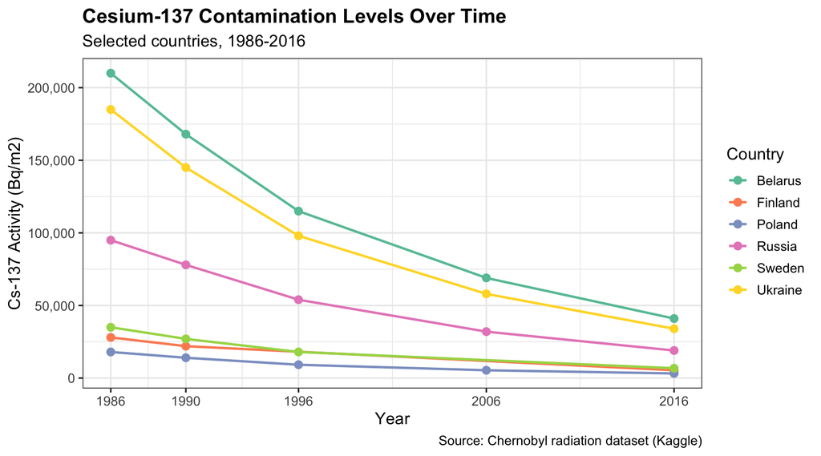

Figure 1. Cs-137 levels declined over time in all countries, but Ukraine and Belarus remain far above the others.